# PHH_EG

Sem

2025-05-06

## Libraries

```r
library(ggplot2)
library(dplyr)
```

## PHH Data

```r
data_dir <- "C:/Users/semde/Documents/BOO_Scripts/Data/PHH_TXG-MAPr"
expression_long   <- readRDS(file.path(data_dir, "expression_long.rds"))
module_definition        <- readRDS(file.path(data_dir, "module_definition.rds"))
eg_score          <- readRDS(file.path(data_dir, "eg_score.rds"))
module_annotation <- readRDS(file.path(data_dir, "module_annotation.rds"))
```

# Introduction

The eigengene scoring method will be evaluated in the Primary Human Hepatocyte (PHH) dataset from the TXG-MAPr tool. It will be evaluated on the Gene Response Rate and Weighted Gene Response Rate (wGRR) metric, which is proposed as an evaluation metric for the topological activation of every unique combination of condition and module. The GRR and wGRR are presented as the following formulas:

$$\mathrm{GRR}(M_j) = \frac{ \displaystyle \sum_{i=1}^{n_j} \left( |\log_2
\mathrm{FC}_i| > 1.0 \,\wedge\, p_{\mathrm{adj},i} < 0.05 \right)}
{ n_j }$$

$$\mathrm{wGRR}(M_j) = \frac{ \displaystyle \sum_{i=1}^{n_j} \left(
|\log_2 \mathrm{FC}_i| > 1.0 \,\wedge\, p_{\mathrm{adj},i} < 0.05
\right) \cdot \mathrm{median(TOM)}_i }{ \sum_{i=1}^{n_j}
\mathrm{median(TOM)}_i }$$
The GRR represents the proportion of significantly expressed genes in a module (abs log2fc > 1.0 and padj < 0.05) and the wGRR weighs this proportion by the median(TOM) of a gene within a module.

# Distribution of Log2FC and adjusted p-value

Distributions will be visualized for insights on the data

## Log2FC

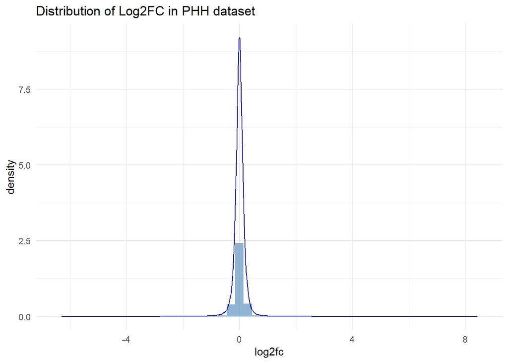

```r
ggplot(expression_long, aes(x = log2fc)) +
  geom_histogram(aes(y = ..density..), bins = 50, fill = "steelblue", alpha = 0.6) +
  geom_density(color = "darkblue") +
  theme_minimal() + labs(title = "Distribution of Log2FC in PHH dataset")
```

Normally distributed visually

```r
sum(abs(expression_long$log2fc) > 1)
```

```
## [1] 77639
```

77639 genes with sig log2fc

## p-adjusted

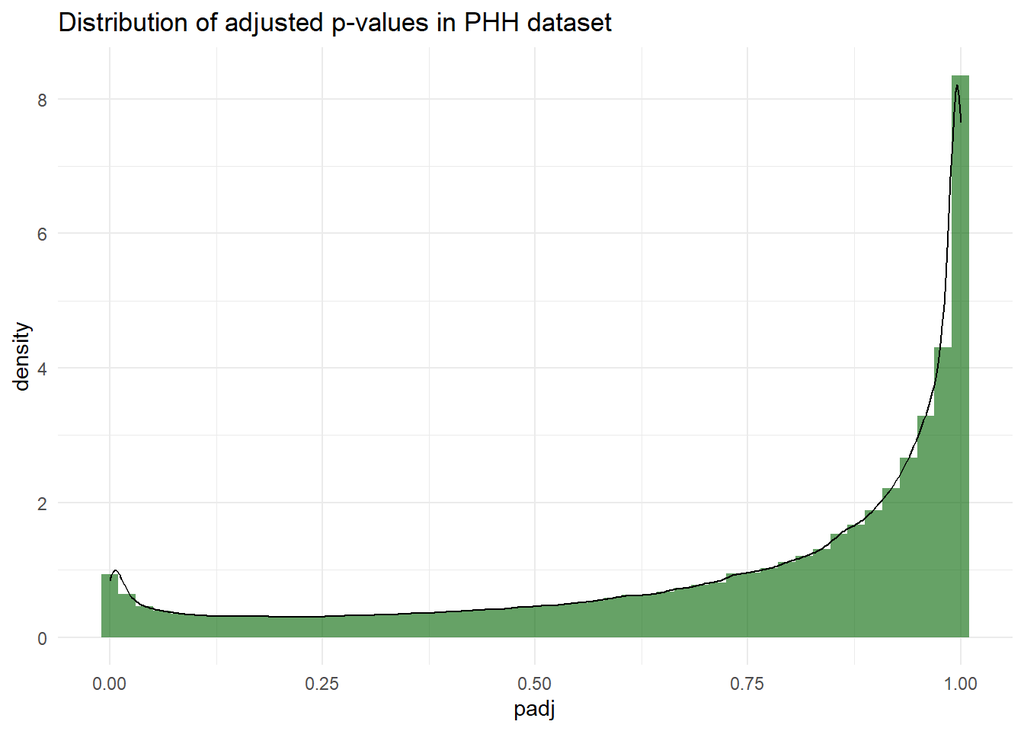

```r
ggplot(expression_long, aes(x = padj)) +
  geom_histogram(aes(y = ..density..), bins = 50, fill = "darkgreen", alpha = 0.6) +
  geom_density(color = "black") +
  theme_minimal() +
  labs(title = "Distribution of adjusted p-values in PHH dataset")
```

Not normally distributed, as expected

```r
sum(expression_long$padj <  0.05)
```

```
## [1] 674354
```

674354 genes with sig padj

## Both Log2FC and padj significant

How many significant genes in the PHH dataset

```r
sum(abs(expression_long$log2fc) > 1 & expression_long$padj < 0.05)
```

```
## [1] 76111
```

76111 genes with both log2fc and padj significant

# Gene Response Rate (GRR)

Here the Gene Response Rate (GRR) will be calculated.

The proposed GRR reflects the total of significant genes (abs(Log2FC) > 1.0 & padj < 0.05) in a module with size n. This will be plotted against the eigengene score to assess this scoring method.

## Merge module_definition with expression_long

Add module_definition to the genes

```r
# Add the modules to the genes in expression_long, don't join with all the variabels -> saves memory

expression_with_module <- expression_long %>%
  select(entrez_id, sample_id, log2fc, padj) %>%
  inner_join(
    module_definition %>% select(entrez_id, module_number, module_size),
    by = "entrez_id"
  ) %>%
  filter(module_number != 0) # Module 0 is irrelevant so delete
```

## Calculate significant genes and total per module

Determine what genes are significant (log2fc > 1.0 and padj < 0.05)

```r
# Calculate significant genes
expression_with_module <- expression_with_module %>%
  mutate(significant = sign(log2fc) * as.numeric(abs(log2fc) > 1 & padj < 0.05))


# Count significant genes per module
sig_count <- expression_with_module %>%
  group_by(module_number, sample_id) %>%
  summarise(sig_genes = sum(significant), .groups = "drop")
```

## Add the module_size to sig_count and calculate GRR

Divide the total significant genes by the module size

```r
sig_count <- sig_count %>%
  left_join(
    expression_with_module %>%
      distinct(module_number, module_size),
    by = "module_number"
  )
```

```r
sig_count <- sig_count %>%
  mutate(GRR = sig_genes / module_size)
```

## Join GRR with EG score per sample

Make a df with the EG_score and corresponding GRR

```r
GRR_vs_eg_score <- sig_count %>%
  inner_join(eg_score, by = c("module_number", "sample_id"))
```

# Weighted Gene Response Rate (wGRR) and (correct) GRR calculation

### Median TOM

Here the median TOM weighted by the Sum of the TOMs (median relative TOM) for the genes within a module are calculated for use in the wGRR calculation

```r
TOM   <- readRDS(file.path(data_dir, "TOM_PHH.rds"))
```

```r
dim(TOM)
```

```
## [1] 10275 10275
```

```r
head(TOM[, 1:5])
```

```
##              id_51514    id_9518    id_2669    id_29760    id_26959
## id_51514  1.000000000 0.06804939 0.03450293 0.008083006 0.065665945
## id_9518   0.068049390 1.00000000 0.02293214 0.006390410 0.052047455
## id_2669   0.034502931 0.02293214 1.00000000 0.002630120 0.042334232
## id_29760  0.008083006 0.00639041 0.00263012 1.000000000 0.005361233
## id_26959  0.065665945 0.05204745 0.04233423 0.005361233 1.000000000
## id_153222 0.063341415 0.06591273 0.05612424 0.008132504 0.076470658
```

This function calculates the median TOM and the relative median TOM

```r
get_module_relative_tom <- function(TOM, gene_module_df) {
  gene_module_df <- gene_module_df %>%
    distinct(entrez_id, module_number) %>%
    filter(entrez_id %in% rownames(TOM))

  gene_module_df %>%
    group_by(module_number) %>%
    group_modify(~ {
      genes <- .x$entrez_id
      sub_tom <- TOM[genes, genes, drop = FALSE]
      diag(sub_tom) <- NA

      tom_median <- matrixStats::rowMedians(sub_tom, na.rm = TRUE)
      total_median <- sum(tom_median, na.rm = TRUE)
      tom_relative <- tom_median / total_median

      tibble(
        entrez_id = genes,
        tom_median = tom_median,
        tom_relative = tom_relative
      )
    }) %>%
    ungroup()
}
```

```r
# Calculate TOM weights
tom_weights <- get_module_relative_tom(TOM, expression_with_module)
```

Check if calc was succesful:

```r
nrow(
  expression_with_module %>%
    distinct(entrez_id, module_number)
) == nrow(tom_weights)
```

```
## [1] TRUE
```

Same number of rows

```r
# Join with expression
expression_with_module <- expression_with_module %>%
  left_join(tom_weights, by = c("entrez_id", "module_number")) %>%
  mutate(tom_median = as.numeric(tom_median), tom_relative = as.numeric(tom_relative))
```

## Calculating the wGRR

Here the wGRR is calculated for each combination of condition and module in the PHH dataset.

```r
weighted_grr_df <- expression_with_module %>%
  # remove module 0
  filter(module_number != 0) %>%

  # double module_size
  select(-module_size) %>%

  # Add per gen corr_egs + module_size
  left_join(
    module_definition %>% select(entrez_id, module_number, corr_egs, module_size),
    by = c("entrez_id", "module_number")
  ) %>%

  # Calculate if the gene is significantly expressed
  mutate(is_significant = sign(log2fc) * as.numeric(abs(log2fc) > 1 & padj < 0.05)) %>%

  # calculate wGRR per combiantion of sample and module
  group_by(sample_id, module_number) %>%
  summarise(
    wGRR = sum(is_significant * tom_relative, na.rm = TRUE),
    module_size = first(module_size),
    .groups = "drop"
  )
```

```r
# Join the calculated wGRR with GRR_vs_eg_score
GRR_vs_eg_score <- GRR_vs_eg_score %>%
  select(-module_size) %>%
  left_join(weighted_grr_df, by = c("sample_id", "module_number"))
```

```r
sum(is.na(GRR_vs_eg_score$wGRR))
```

```
## [1] 0
```

No NA values in wGRR

```r
min(GRR_vs_eg_score$wGRR)
```

```
## [1] -1
```

```r
max(GRR_vs_eg_score$wGRR)
```

```
## [1] 1
```

Reach of -1 to 1 as intended.

```r
#saveRDS(GRR_vs_eg_score, file = "GRR_vs_eg_score_PHH.rds")
```

## Density plots of GRR and EG score

Inspect the distribution of the GRR, EG and abs EG.

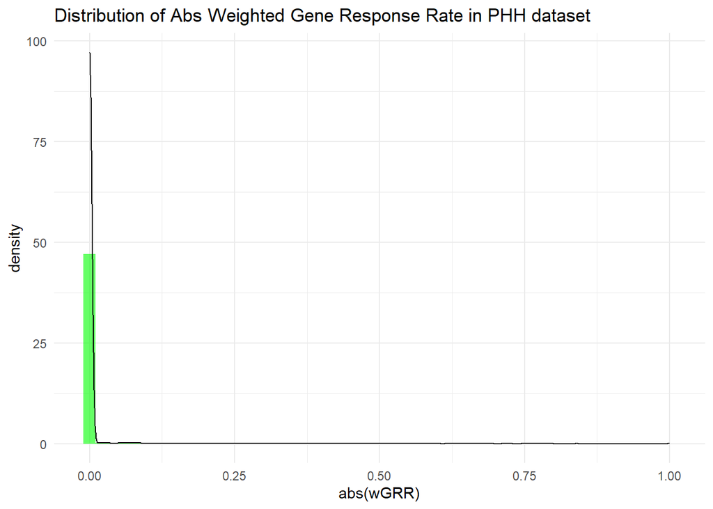

```r
ggplot(GRR_vs_eg_score, aes(x = abs(wGRR))) +
  geom_histogram(aes(y = ..density..), bins = 50, fill = "green", alpha = 0.6) +
  geom_density(color = "black") +
  theme_minimal() + labs(title = "Distribution of Abs Weighted Gene Response Rate in PHH dataset")
```

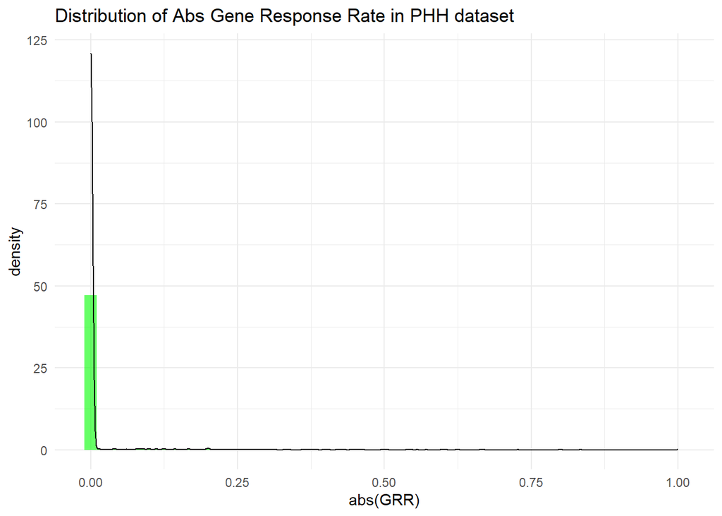

```r
ggplot(GRR_vs_eg_score, aes(x = abs(GRR))) +
  geom_histogram(aes(y = ..density..), bins = 50, fill = "green", alpha = 0.6) +
  geom_density(color = "black") +
  theme_minimal() + labs(title = "Distribution of Abs Gene Response Rate in PHH dataset")
```

Both abs GRR and abs wGRR log distributed, as expected due to Abs transformation.

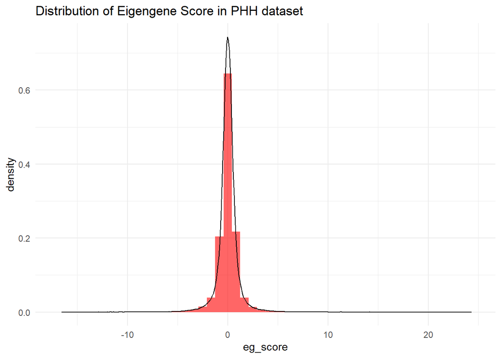

```r
ggplot(GRR_vs_eg_score, aes(x = eg_score)) +
  geom_histogram(aes(y = ..density..), bins = 50, fill = "red", alpha = 0.6) +
  geom_density(color = "black") +
  theme_minimal() + labs(title = "Distribution of Eigengene Score in PHH dataset")
```

Eigengene shows a normal distribution, as expected due to the PCA use.

# Fitting GRR and wGRR vs EG score using Binomial GLMs

### GRR

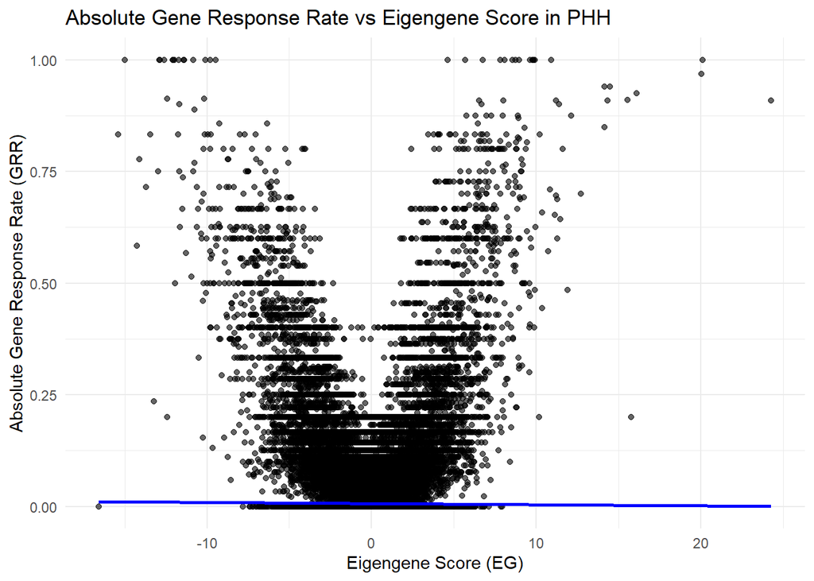

```r
ggplot(GRR_vs_eg_score, aes(x = eg_score, y = abs(GRR))) +
  geom_point(alpha = 0.6) +
  geom_smooth(method = "lm", se = FALSE, color = "blue") +
  theme_minimal() +
  labs(
    title = "Absolute Gene Response Rate vs Eigengene Score in PHH",
    x = "Eigengene Score (EG)",
    y = "Absolute Gene Response Rate (GRR)"
  )
```

### wGRR

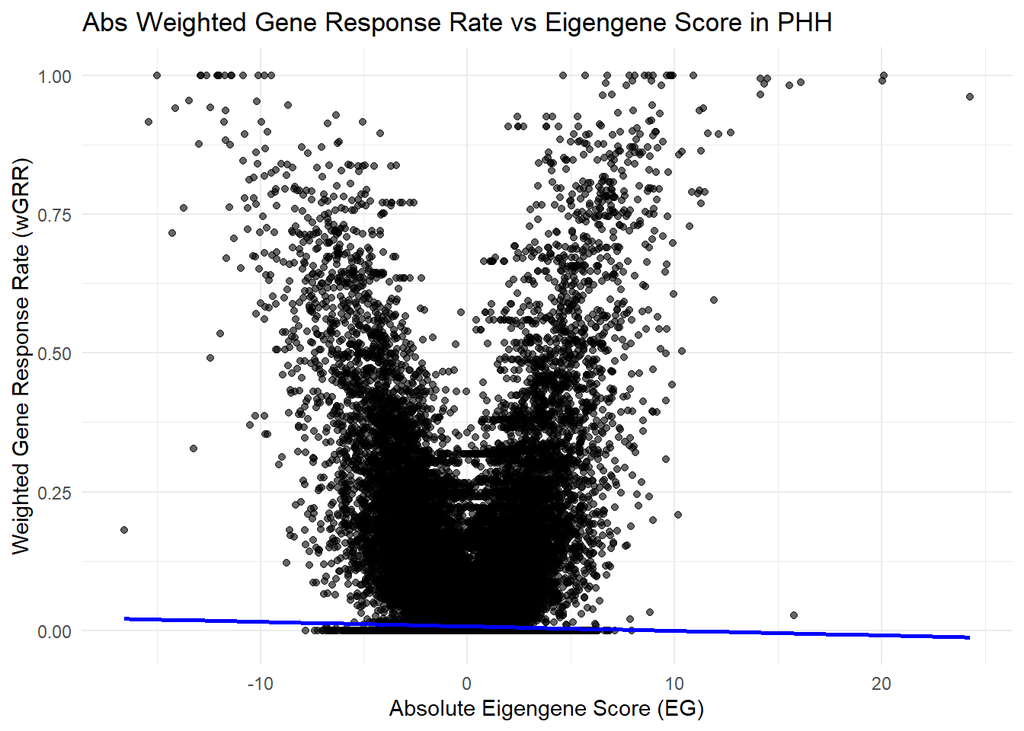

```r
ggplot(GRR_vs_eg_score, aes(x = eg_score, y = abs(wGRR))) +
  geom_point(alpha = 0.6) +
  geom_smooth(method = "lm", se = FALSE, color = "blue") +
  theme_minimal() +
  labs(
    title = "Abs Weighted Gene Response Rate vs Eigengene Score in PHH",
    x = "Absolute Eigengene Score (EG)",
    y = "Weighted Gene Response Rate (wGRR)"
  )
```

The linear fit does not follow the trend of the (w)GRR vs EG, as expected due to the logarithmic distribution of the (w)GRR. Next we will try to fit a binomal fit

## Fitting using Binomial Generalized Linear Model (GLM)

The data will be fitted with a binomial GLM to assess the general trend and later determine outlying modules from this trend

### GRR

```r
glm_data <- GRR_vs_eg_score %>%
  filter(!is.na(GRR), !is.na(eg_score)) # This filtering was performed as the function was first tested on a subset, but the filtering is irrelevant for the whole dataset as there are no NAs
```

```r
glm_fit <- glm(
  abs(GRR) ~ abs(eg_score), # absolute because of binomial
  data = glm_data,
  family = quasibinomial(link = "logit") # quasibinomial as the GRR is a proportion
)
```

```r
# Make predictions and residuals
glm_predictions <- predict(glm_fit, type = "response")
glm_dev_resid <- residuals(glm_fit, type = "deviance")

# Combine into a new dataframe
GRR_glm_fit_df <- glm_data %>%
  mutate(
    fitted_GRR = glm_predictions,
    GRR_resid = abs(GRR) - fitted_GRR,
    dev_resid = glm_dev_resid
  )
```

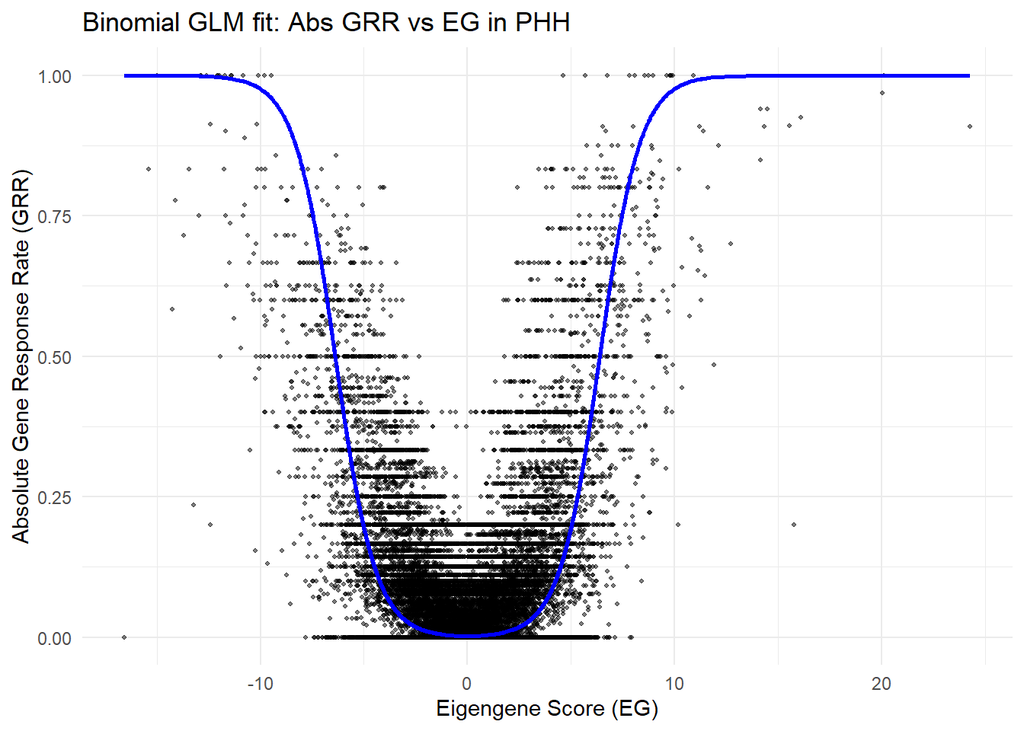

```r
ggplot(GRR_glm_fit_df, aes(x = eg_score, y = abs(GRR))) +
  geom_point(alpha = 0.5, size = 0.8) +
  geom_line(aes(y = fitted_GRR), color = "blue", size = 1) +
  theme_minimal() +
  labs(
    title = "Binomial GLM fit: Abs GRR vs EG in PHH",
    x = "Eigengene Score (EG)",
    y = "Absolute Gene Response Rate (GRR)"
  )
```

A lot of points with high scores and low gene response and low scores with high GRR. good fit visually

```r
summary(glm_fit)
```

```
##
## Call:
## glm(formula = abs(GRR) ~ abs(eg_score), family = quasibinomial(link = "logit"),
##     data = glm_data)
##
## Coefficients:
##               Estimate Std. Error t value Pr(>|t|)
## (Intercept)   -6.54537    0.05364 -122.03   <2e-16 ***
## abs(eg_score)  1.02419    0.01555   65.85   <2e-16 ***
## ---
## Signif. codes:  0 '***' 0.001 '**' 0.01 '*' 0.05 '.' 0.1 ' ' 1
##
## (Dispersion parameter for quasibinomial family taken to be 2.232821)
##
##     Null deviance: 18396.9  on 374517  degrees of freedom
## Residual deviance:  8347.5  on 374516  degrees of freedom
## AIC: NA
##
## Number of Fisher Scoring iterations: 8
```

Good fit statistically.

### significant outliers

For each module and sample, we compare the observed number of significant genes to the expected number based on the binomial GLM, and calculate a two-sided z-score and p-value using the binomial standard error. By doing this, the significant outlying modules from the glm fit are identified.

```r
GRR_glm_fit_df <- GRR_glm_fit_df %>%
  mutate(
    se_fit = sqrt(fitted_GRR * (1 - fitted_GRR) / module_size),
    z_score = GRR_resid / se_fit,
    p_value = 2 * pnorm(-abs(z_score))  # two-sided test
  )
```

```r
GRR_glm_fit_df <- GRR_glm_fit_df %>%
  mutate(
    outlier = p_value < 0.05,
    outlier_direction = case_when(
      outlier & z_score > 0 ~ "Above fit",
      outlier & z_score < 0 ~ "Below fit",
      TRUE ~ "Not significant"
    )
  )
```

```r
GRR_glm_fit_df <- GRR_glm_fit_df %>%
  mutate(module = paste0("hPHH_", module_number)) %>%
  left_join(module_annotation, by = "module")
```

```r
sum(GRR_glm_fit_df$outlier, na.rm = TRUE)
```

```
## [1] 10464
```

There are 10464 outliers found from the binomial fit in PHH for the GRR

```r
total_modules_all <- GRR_glm_fit_df %>%
  filter(module_number != 0) %>%
  summarise(n = n_distinct(module_number)) %>%
  pull(n) # for normalization
```

```r
total_conditions_all <- GRR_glm_fit_df %>%
  filter(module_number != 0) %>%
  summarise(n = n_distinct(sample_id)) %>%
  pull(n) # for normalization
```

```r
# Make a summarizing df for comparing with other datasets and scoring algorithms
outlier_density <- GRR_glm_fit_df %>%
  filter(outlier, module_number != 0) %>%
  group_by(outlier_direction) %>%
  summarise(
    total_outliers = n(),
    .groups = "drop"
  ) %>%
  bind_rows(
    tibble(
      outlier_direction = "Total",
      total_outliers = sum(.$total_outliers)
    )
  ) %>%
  mutate(
    total_modules = total_modules_all,
    total_conditions = total_conditions_all,
    density = total_outliers / (total_modules * total_conditions)
  )
```

```r
print(outlier_density)
```

```
## # A tibble: 3 × 5
##   outlier_direction total_outliers total_modules total_conditions density
##   <chr>                      <int>         <int>            <int>   <dbl>
## 1 Above fit                   9415           398              941 0.0251
## 2 Below fit                   1049           398              941 0.00280
## 3 Total                      10464           398              941 0.0279
```

Above shows the density of the outliers: number of outliers / (total conditions * total modules).

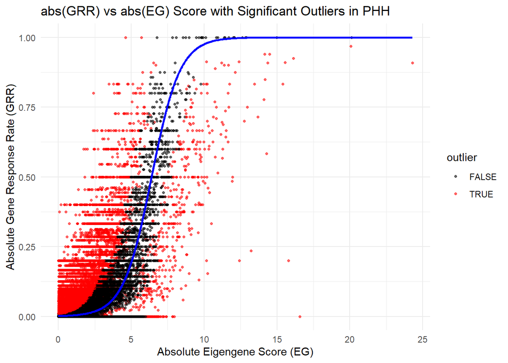

```r
ggplot(GRR_glm_fit_df, aes(x = abs(eg_score), y = abs(GRR))) +
  geom_point(aes(color = outlier), alpha = 0.6, size = 0.9) +
  geom_line(aes(y = fitted_GRR), color = "blue", size = 1) +
  scale_color_manual(values = c("black", "red")) +
  theme_minimal() +
  labs(
    title = "abs(GRR) vs abs(EG) Score with Significant Outliers in PHH",
    x = "Absolute Eigengene Score (EG)",
    y = "Absolute Gene Response Rate (GRR)"
  )
```

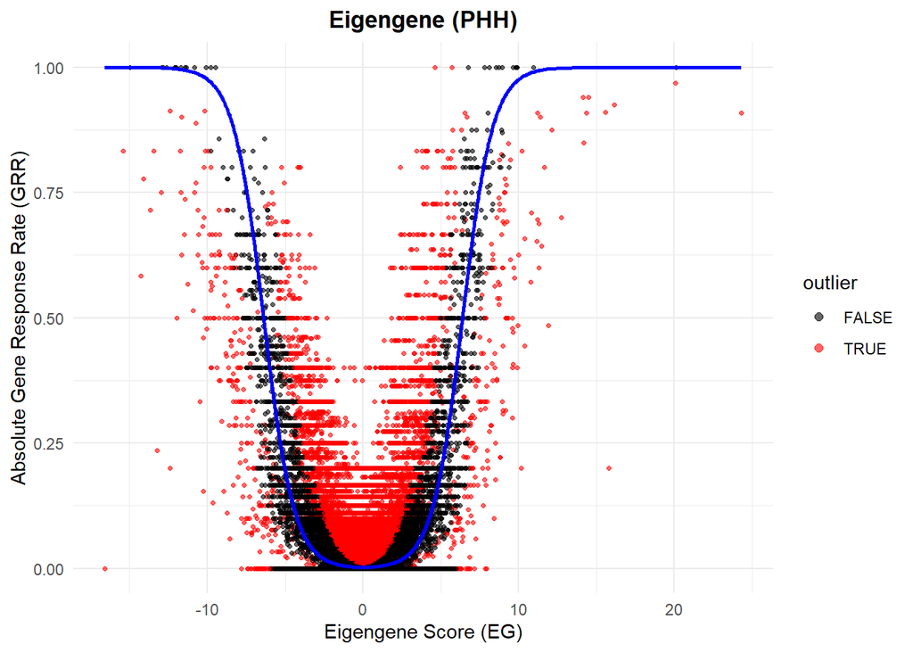

```r
ggplot(GRR_glm_fit_df, aes(x = eg_score, y = abs(GRR))) +
  geom_point(aes(color = outlier), alpha = 0.6, size = 0.9) +
  geom_line(aes(y = fitted_GRR), color = "blue", size = 1) +
  scale_color_manual(values = c("black", "red")) +
  theme_minimal() + theme(plot.title = element_text(hjust = 0.5, face = "bold")) +
  guides(color = guide_legend(override.aes = list(size = 2))) +
  labs(
    title = "Eigengene (PHH)",
    x = "Eigengene Score (EG)",
    y = "Absolute Gene Response Rate (GRR)"
  )
```

### wGRR

```r
glm_data <- GRR_vs_eg_score %>%
  filter(!is.na(wGRR), !is.na(eg_score), abs(wGRR)<=1) # This filtering was performed as the function was first tested on a subset, but the filtering is irrelevant for the whole dataset as there are no NAs. Also one value of wGRR was above 1?
```

```r
glm_fit <- glm(
  abs(wGRR) ~ abs(eg_score), # Absolute because of binomial fit
  data = glm_data,
  family = quasibinomial(link = "logit") # quasibinomial as the wGRR is a proportion multiplied by a continuous variable, the median TOM
)
```

```r
# Make predictions and residuals
glm_predictions <- predict(glm_fit, type = "response")
glm_dev_resid <- residuals(glm_fit, type = "deviance")

# Combine into a new dataframe
GRR_glm_fit_df <- glm_data %>%
  mutate(
    fitted_wGRR = glm_predictions,
    wGRR_resid = abs(wGRR) - fitted_wGRR,
    dev_resid = glm_dev_resid
  )
```

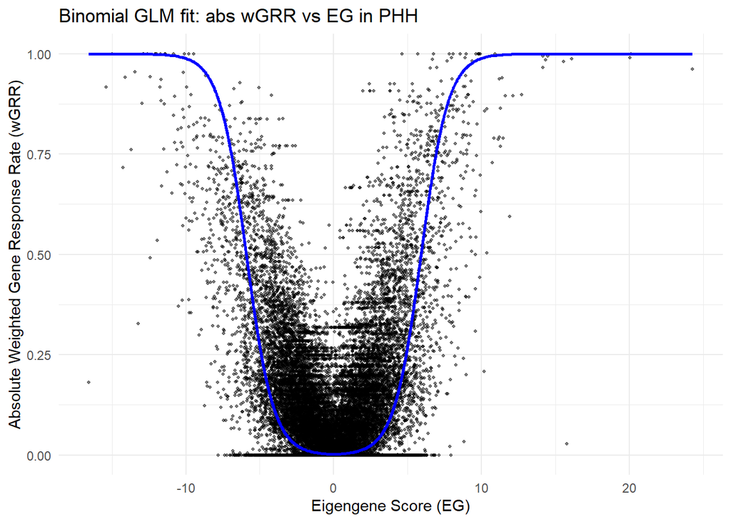

```r
ggplot(GRR_glm_fit_df, aes(x = eg_score, y = abs(wGRR))) +
  geom_point(alpha = 0.5, size = 0.8) +
  geom_line(aes(y = fitted_wGRR), color = "blue", size = 1) +
  theme_minimal() +
  labs(
    title = "Binomial GLM fit: abs wGRR vs EG in PHH",
    x = "Eigengene Score (EG)",
    y = "Absolute Weighted Gene Response Rate (wGRR)"
  )
```

```r
summary(glm_fit)
```

```
##
## Call:
## glm(formula = abs(wGRR) ~ abs(eg_score), family = quasibinomial(link = "logit"),
##     data = glm_data)
##
## Coefficients:
##               Estimate Std. Error t value Pr(>|t|)
## (Intercept)   -6.43173    0.05170 -124.39   <2e-16 ***
## abs(eg_score)  1.08744    0.01567   69.42   <2e-16 ***
## ---
## Signif. codes:  0 '***' 0.001 '**' 0.01 '*' 0.05 '.' 0.1 ' ' 1
##
## (Dispersion parameter for quasibinomial family taken to be 2.357453)
##
##     Null deviance: 22796  on 374516  degrees of freedom
## Residual deviance: 10208  on 374515  degrees of freedom
## AIC: NA
##
## Number of Fisher Scoring iterations: 8
```

Visually and statistically a good fit

### significant outliers

For each module and sample, we compare the observed number of significant genes to the expected number based on the binomial GLM, and calculate a two-sided z-score and p-value using the binomial standard error. By doing this, the significant outlying modules from the glm fit are identified.

```r
GRR_glm_fit_df <- GRR_glm_fit_df %>%
  mutate(
    se_fit = sqrt(fitted_wGRR * (1 - fitted_wGRR) / module_size),
    z_score = wGRR_resid / se_fit,
    p_value = 2 * pnorm(-abs(z_score))  # two-sided test
  )
```

```r
GRR_glm_fit_df <- GRR_glm_fit_df %>%
  mutate(
    outlier = p_value < 0.05,
    outlier_direction = case_when(
      outlier & z_score > 0 ~ "Above fit",
      outlier & z_score < 0 ~ "Below fit",
      TRUE ~ "Not significant"
    )
  )
```

```r
GRR_glm_fit_df <- GRR_glm_fit_df %>%
  mutate(module = paste0("hPHH_", module_number)) %>%
  left_join(module_annotation, by = "module")
```

```r
sum(GRR_glm_fit_df$outlier, na.rm = TRUE)
```

```
## [1] 10654
```

There are 10654 outliers found from the binomial fit of wGRR vs EG.

```r
total_modules_all <- GRR_glm_fit_df %>%
  filter(module_number != 0) %>%
  summarise(n = n_distinct(module_number)) %>%
  pull(n) # for normalization
```

```r
total_conditions_all <- GRR_glm_fit_df %>%
  filter(module_number != 0) %>%
  summarise(n = n_distinct(sample_id)) %>%
  pull(n) # for normalization
```

```r
# Make a summarizing df for comparing with other datasets and scoring algorithms
outlier_density <- GRR_glm_fit_df %>%
  filter(outlier, module_number != 0) %>%
  group_by(outlier_direction) %>%
  summarise(
    total_outliers = n(),
    .groups = "drop"
  ) %>%
  bind_rows(
    tibble(
      outlier_direction = "Total",
      total_outliers = sum(.$total_outliers)
    )
  ) %>%
  mutate(
    total_modules = total_modules_all,
    total_conditions = total_conditions_all,
    density = total_outliers / (total_modules * total_conditions)
  )
```

```r
print(outlier_density)
```

```
## # A tibble: 3 × 5
##   outlier_direction total_outliers total_modules total_conditions density
##   <chr>                      <int>         <int>            <int>   <dbl>
## 1 Above fit                   9311           398              941 0.0249
## 2 Below fit                   1343           398              941 0.00359
## 3 Total                      10654           398              941 0.0284
```

Above shows the density of the outliers: number of outliers / (total conditions * total modules).

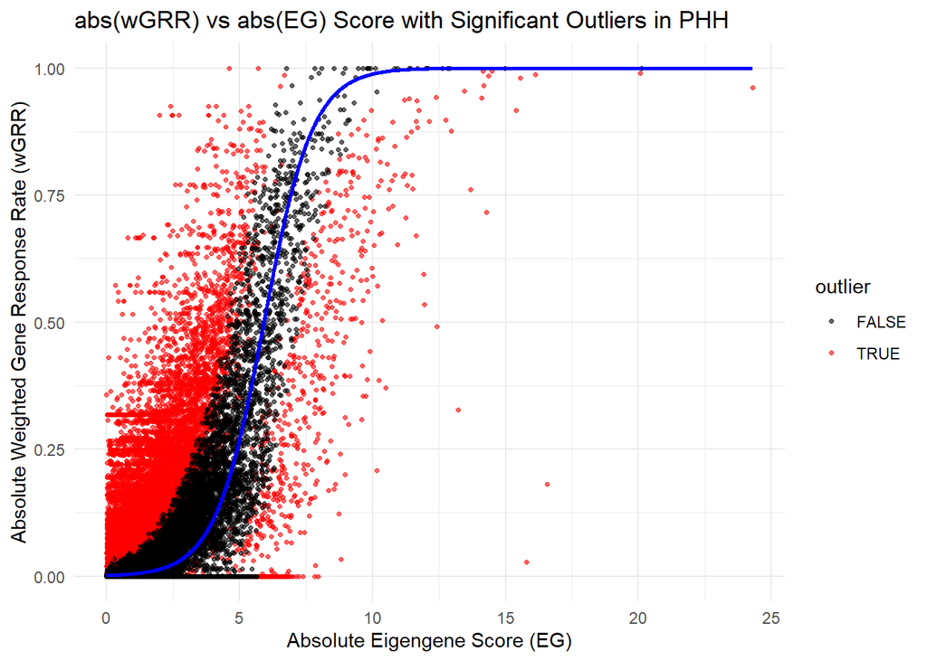

```r
ggplot(GRR_glm_fit_df, aes(x = abs(eg_score), y = abs(wGRR))) +
  geom_point(aes(color = outlier), alpha = 0.6, size = 0.9) +
  geom_line(aes(y = fitted_wGRR), color = "blue", size = 1) +
  scale_color_manual(values = c("black", "red")) +
  theme_minimal() +
  labs(
    title = "abs(wGRR) vs abs(EG) Score with Significant Outliers in PHH",
    x = "Absolute Eigengene Score (EG)",
    y = "Absolute Weighted Gene Response Rate (wGRR)"
  )
```

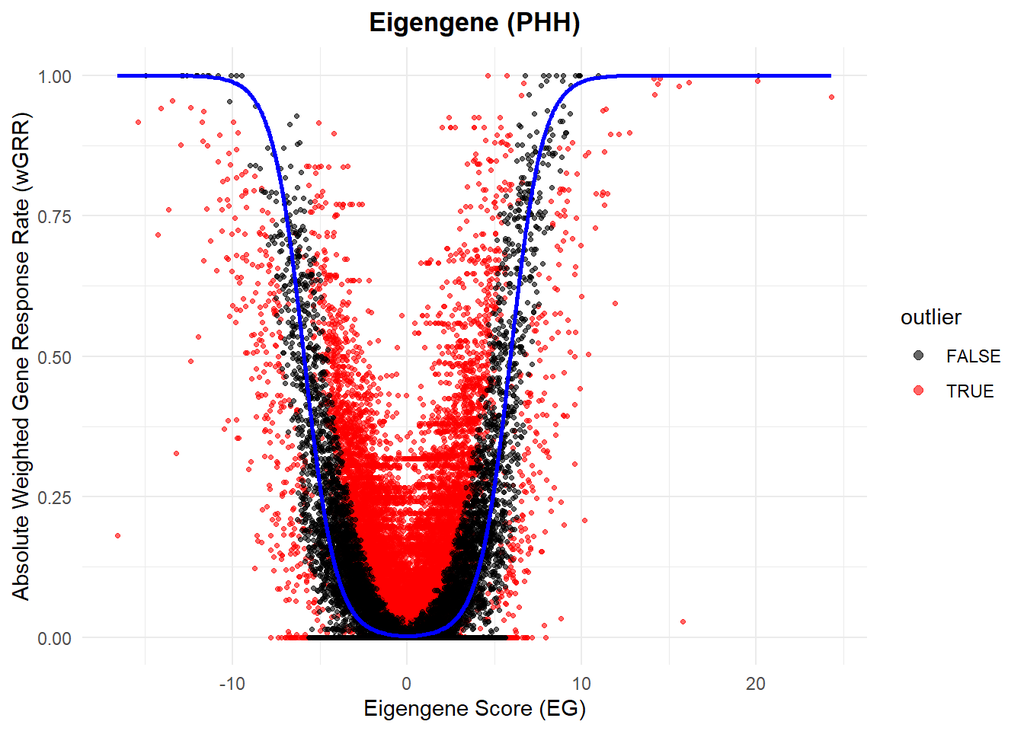

```r
ggplot(GRR_glm_fit_df, aes(x = eg_score, y = abs(wGRR))) +
  geom_point(aes(color = outlier), alpha = 0.6, size = 0.9) +
  geom_line(aes(y = fitted_wGRR), color = "blue", size = 1) +
  scale_color_manual(values = c("black", "red")) +
  theme_minimal() + theme(plot.title = element_text(hjust = 0.5, face = "bold")) +
  guides(color = guide_legend(override.aes = list(size = 2))) +
  labs(
    title = "Eigengene (PHH)",
    x = "Eigengene Score (EG)",
    y = "Absolute Weighted Gene Response Rate (wGRR)"
  )
```

# Modules and conditions with most significant outliers’

Based on the wGRR binomial GLM fit, we will now find the modules and conditions with the most significant outliers

```r
significant_outliers_filtered <- GRR_glm_fit_df %>%
  filter(outlier)
```

```r
outliers_per_module <- significant_outliers_filtered %>%
  count(module_number, sort = TRUE)
```

```r
outliers_per_sample <- significant_outliers_filtered %>%
  count(sample_id, sort = TRUE)
```

```r
head(outliers_per_module, 10) # Top modules with outliers
```

```
## # A tibble: 10 × 2
##    module_number     n
##            <dbl> <int>
##  1             1   717
##  2            44   232
##  3            11   198
##  4             2   180
##  5            15   179
##  6             3   166
##  7             4   154
##  8           134   152
##  9           358   148
## 10            86   147
```

```r
head(outliers_per_sample, 10) # Top cconditions with outliers
```

```
## # A tibble: 10 × 2
##    sample_id                                n
##    <chr>                                <int>
##  1 TG_HPHH_SINGLE_CYCLOHEXIMIDE_T3_C3     173
##  2 TG_HPHH_SINGLE_ETHIONINE_T3_C3         159
##  3 TG_HPHH_SINGLE_DOXORUBICIN_T3_C3       141
##  4 TG_HPHH_SINGLE_DOXORUBICIN_T3_C2       124
##  5 TG_HPHH_SINGLE_CYCLOHEXIMIDE_T3_C2     117
##  6 TG_HPHH_SINGLE_SULINDAC_T3_C3          117
##  7 TG_HPHH_SINGLE_COLCHICINE_T3_C3        113
##  8 TG_HPHH_SINGLE_PHENOBARBITAL_T3_C3     112
##  9 TG_HPHH_SINGLE_BROMOETHYLAMINE_T3_C3   110
## 10 TG_HPHH_SINGLE_THEOPHYLLINE_T3_C3      108
```

### Outliers per module: total, below and above the fit with human annotation

Here, we will visualize the modules with the most outliers. Total, below and above the Binomial GLM fit.

#### Total outliers from the GLM fit

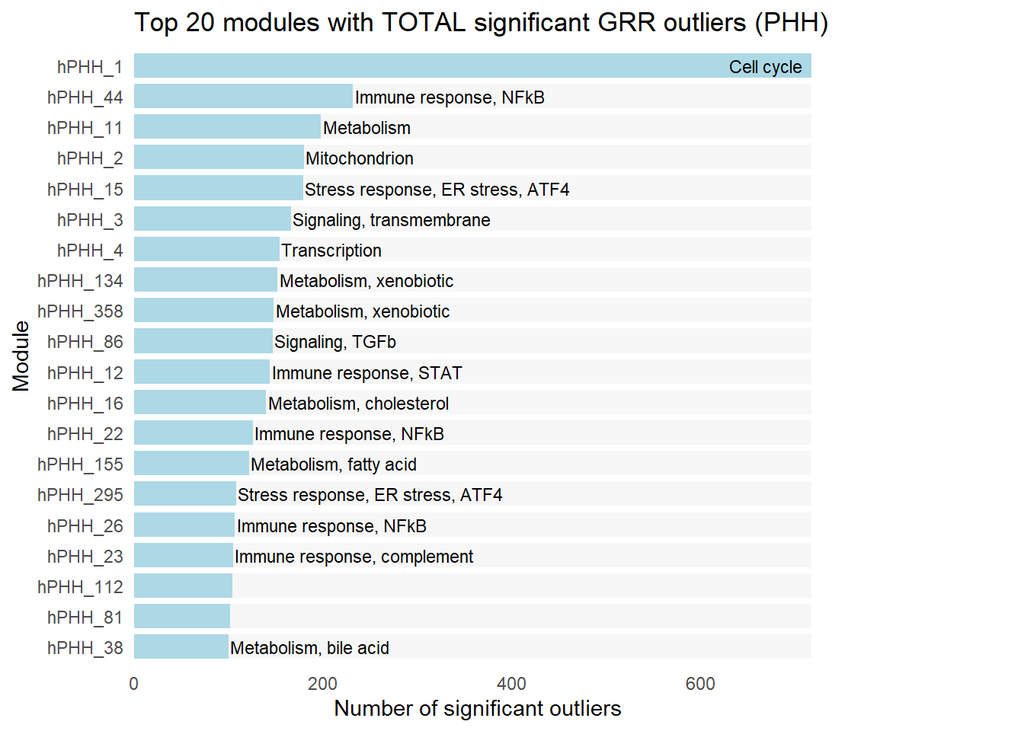

```r
threshold <- 300  # Threshold for annotation

GRR_glm_fit_df %>%
  filter(outlier) %>%
  count(module, annotation, sort = TRUE) %>%
  slice_max(n, n = 20, with_ties = FALSE) %>%
  mutate(
    max_n = max(n),
    hjust_val = ifelse(n < threshold, 0, 1.1),
    label_pos = ifelse(n < threshold, n + 2, n - 2)
  ) %>%
  ggplot(aes(x = reorder(module, n))) +
  geom_col(aes(y = max_n), fill = "grey97", width = 0.8) +
  geom_col(aes(y = n), fill = "lightblue", width = 0.8) +
  geom_text(
    aes(y = label_pos, label = annotation, hjust = hjust_val),
    size = 3, color = "black"
  ) +
  coord_flip(clip = "off") +
  scale_y_continuous(
    limits = c(0, max(GRR_glm_fit_df %>%
      filter(outlier) %>%
      count(module) %>%
      slice_max(n, n = 20, with_ties = FALSE) %>%
      pull(n)) + 10),
    expand = c(0, 0)
  ) +
  theme_minimal() +
  theme(
    plot.margin = margin(5.5, 100, 5.5, 5.5),
    panel.grid.major = element_blank(),
    panel.grid.minor = element_blank()
  ) +
  labs(
    title = "Top 20 modules with TOTAL significant GRR outliers (PHH)",
    x = "Module",
    y = "Number of significant outliers"
  )
```

#### Outliers above the GLM fit

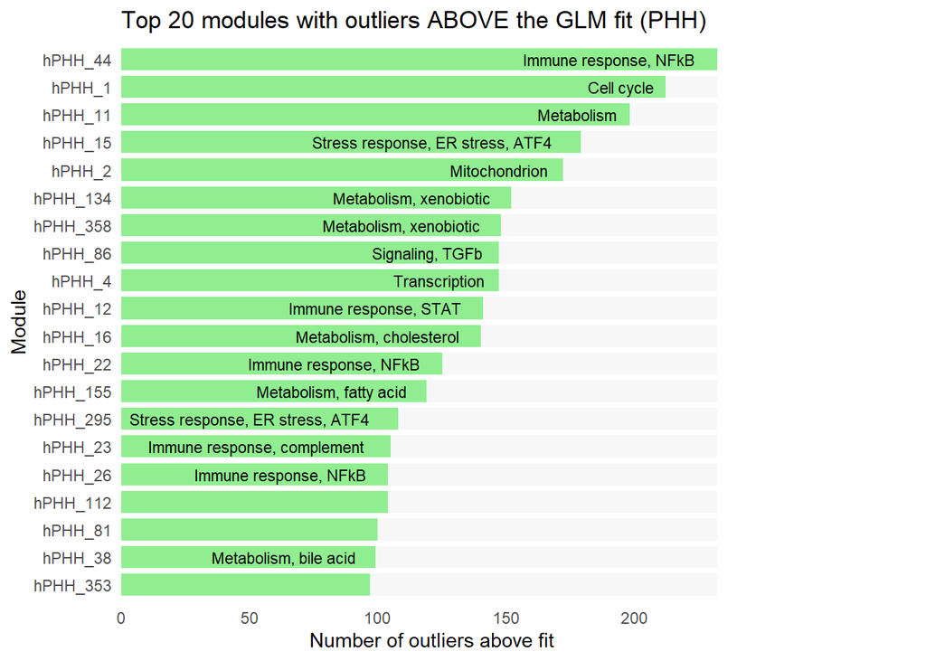

```r
threshold <- 0  # Threshold for switching annotation position

GRR_glm_fit_df %>%
  filter(outlier_direction == "Above fit") %>%
  count(module, annotation, sort = TRUE) %>%
  slice_max(n, n = 20, with_ties = FALSE) %>%
  mutate(
    max_n = max(n),
    hjust_val = ifelse(n < threshold, 0, 1.1),
    label_pos = ifelse(n < threshold, n + 2, n - 2)
  ) %>%
  ggplot(aes(x = reorder(module, n))) +
  geom_col(aes(y = max_n), fill = "grey97", width = 0.8) +
  geom_col(aes(y = n), fill = "lightgreen", width = 0.8) +
  geom_text(
    aes(y = label_pos, label = annotation, hjust = hjust_val),
    size = 3, color = "black"
  ) +
  coord_flip(clip = "off") +
  scale_y_continuous(
    limits = c(0, max(GRR_glm_fit_df %>%
      filter(outlier_direction == "Above fit") %>%
      count(module) %>%
      slice_max(n, n = 20, with_ties = FALSE) %>%
      pull(n)) + 10),
    expand = c(0, 0)
  ) +
  theme_minimal() +
  theme(
    plot.margin = margin(5.5, 100, 5.5, 5.5),
    panel.grid.major = element_blank(),
    panel.grid.minor = element_blank()
  ) +
  labs(
    title = "Top 20 modules with outliers ABOVE the GLM fit (PHH)",
    x = "Module",
    y = "Number of outliers above fit"
  )
```

#### Outliers below the GLM fit

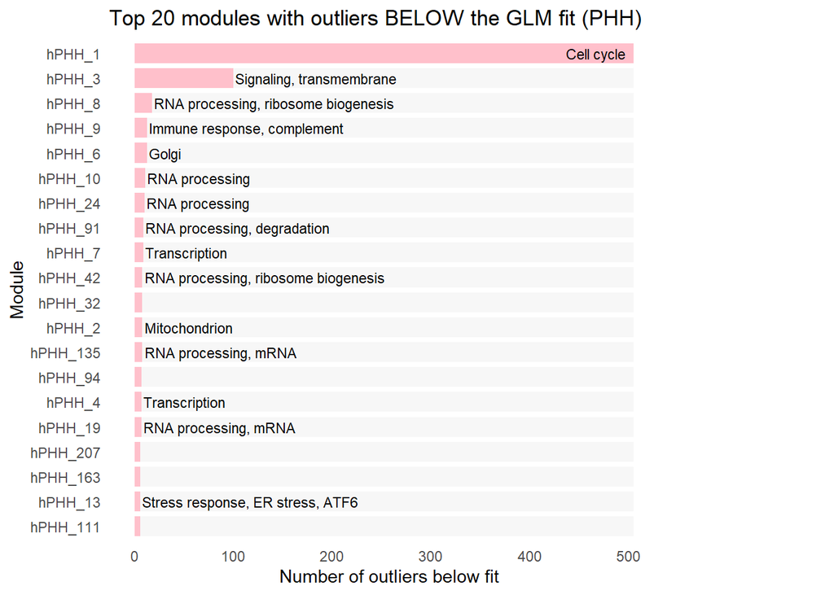

```r
threshold <- 200  # Threshold for annotation in plot

GRR_glm_fit_df %>%
  filter(outlier_direction == "Below fit") %>%
  count(module, annotation, sort = TRUE) %>%
  slice_max(n, n = 20, with_ties = FALSE) %>%
  mutate(
    max_n = max(n),
    hjust_val = ifelse(n < threshold, 0, 1.1),       # outside or inside
    label_pos = ifelse(n < threshold, n + 2, n - 2)  # offset label position
  ) %>%
  ggplot(aes(x = reorder(module, n))) +

  # Background bar
  geom_col(aes(y = max_n), fill = "grey97", width = 0.8) +

  # Foreground bar (actual value)
  geom_col(aes(y = n), fill = "pink", width = 0.8) +

  # Smart annotation positioning
  geom_text(
    aes(y = label_pos, label = annotation, hjust = hjust_val),
    size = 3, color = "black"
  ) +

  coord_flip(clip = "off") +  # Flip axes for horizontal bars

  # Y-axis limits: no exessive white space
  scale_y_continuous(limits = c(0, max(GRR_glm_fit_df %>%
    filter(outlier_direction == "Below fit") %>%
    count(module) %>%
    slice_max(n, n = 20, with_ties = FALSE) %>%
    pull(n)) + 10)) +

  theme_minimal() +
  theme(
    plot.margin = margin(5.5, 100, 5.5, 5.5),
    panel.grid.major = element_blank(),
    panel.grid.minor = element_blank()
  ) +
  labs(
    title = "Top 20 modules with outliers BELOW the GLM fit (PHH)",
    x = "Module",
    y = "Number of outliers below fit"
  )
```

### Outliers per sample: above, below and total.

Now, we will assess what conditions have the most outliers. Total, below and above the binomial GLM fit.

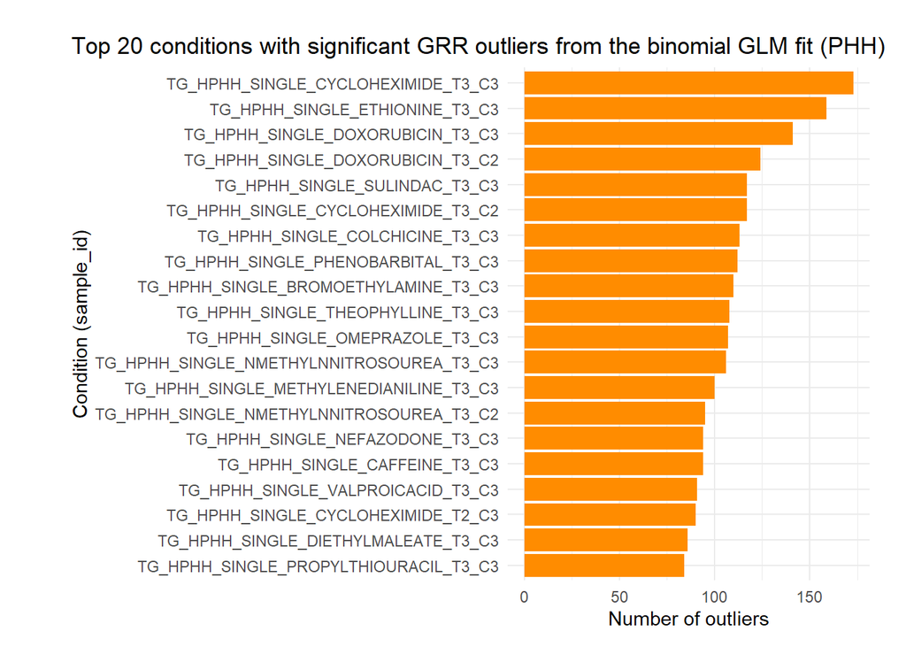

```r
outliers_per_sample %>%
  top_n(20, n) %>%
  ggplot(aes(x = reorder(sample_id, n), y = n)) +
  geom_col(fill = "darkorange") +
  coord_flip() +
  theme_minimal() +
  ggtitle("Top 20 conditions with significant GRR outliers from the binomial GLM fit (PHH)") +
  theme(
    plot.title.position = "plot",
    plot.title = element_text(hjust = 0),
    plot.margin = margin(20, 20, 10, 40) # top, right, bottom, left
  ) +
  labs(
    x = "Condition (sample_id)",
    y = "Number of outliers"
  )
```

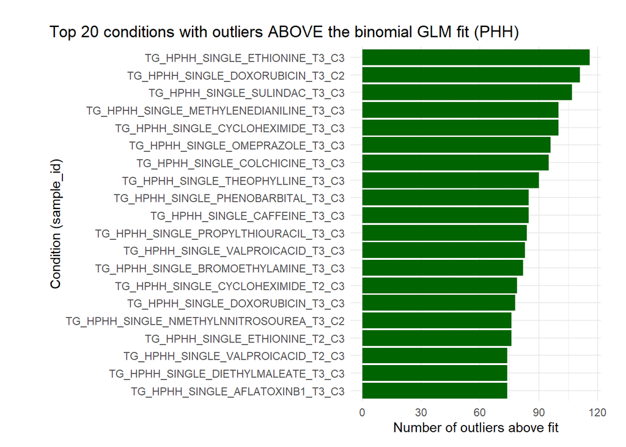

```r
GRR_glm_fit_df %>%
  filter(outlier_direction == "Above fit") %>%
  count(sample_id, sort = TRUE) %>%
  top_n(20, n) %>%
  ggplot(aes(x = reorder(sample_id, n), y = n)) +
  geom_col(fill = "darkgreen") +
  coord_flip() +
  theme_minimal() +
  ggtitle("Top 20 conditions with outliers ABOVE the binomial GLM fit (PHH)") +
  theme(
    plot.title.position = "plot",
    plot.title = element_text(hjust = 0),
    plot.margin = margin(20, 20, 10, 40)
  ) +
  labs(
    x = "Condition (sample_id)",
    y = "Number of outliers above fit"
  )
```

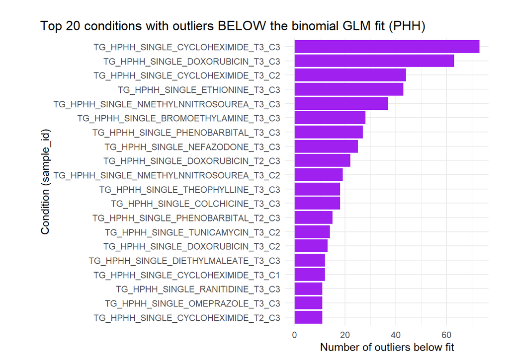

```r
GRR_glm_fit_df %>%
  filter(outlier_direction == "Below fit") %>%
  count(sample_id, sort = TRUE) %>%
  top_n(20, n) %>%
  ggplot(aes(x = reorder(sample_id, n), y = n)) +
  geom_col(fill = "purple") +
  coord_flip() +
  theme_minimal() +
  ggtitle("Top 20 conditions with outliers BELOW the binomial GLM fit (PHH)") +
  theme(
    plot.title.position = "plot",
    plot.title = element_text(hjust = 0),
    plot.margin = margin(20, 20, 10, 40)
  ) +
  labs(
    x = "Condition (sample_id)",
    y = "Number of outliers below fit"
  )
```

# Conclusion

The Eigengene score shows improveable performance on the GRR and wGRR metrics in the PHH dataset. There are lots of low EG scores with high GRR and wGRR points and there are some high EG scores with low GRR and wGRR points. The aim is to improve this using the Weighted Directed Random Walk algorithm, which will be assessed in the hPHH_wDRW.Rmd file.